# DAT Project Group E

DASC 360: Multivariate Data Analysis

Bryce Pacourek, Tyler Johnson, Reilly Kurth, Munir Abdikadir

2026-10-16

#### Load Relevant R Libraries

```r
library(rmarkdown); library(knitr); library(moments);
library(scatterplot3d); library(corrplot); library(pso)
library(psych); library(GPArotation); library(lavaan);
library(tidyverse); library(GGally); library(dplyr);
```

## DAT

We accessed our data from the [World Bank World Development Indicators](https://databank.worldbank.org/)

### 1. Load Data

```r
df <- read.csv("https://github.com/kurt8267/DASC360-Group-E-Project-/raw/refs/heads/main/final-vars-long.csv")
df <- df[1:480, c(1, 3, 5)]
df <-
  df %>%
  pivot_wider(
    id_cols = "Country.Name",
    names_from = "Series.Name",
    values_from = "X2019..YR2019."
  )
data_mat <- matrix(
  data = as.double(t(df)),
  byrow = TRUE,
  nrow = 48,
  dimnames = list(
    df$Country.Name,
    names(df)
  )
)
data_mat <- data_mat[,-1]
data_mat <- data_mat[,which(4 > colSums(is.na(data_mat)))]
colnames(data_mat) <- c("gdp_c",
                        "dth_p",
                        "san",
                        "ela",
                        "pop_g",
                        "gdp_g",
                        "dth_k",
                        "dth_d",
                        "dth_c")
data_mat <- data_mat[, c("san",
                         "ela",
                         "gdp_c",
                         "gdp_g",
                         "pop_g",
                         "dth_c",
                         "dth_d",
                         "dth_k",
                         "dth_p")]
```

### Describe source and process used to download data

There is a graphical user interface where countries, variables, and years of collection can be selected. The data is then loaded into a table in the GUI, which can be exported as an Excel file or CSV.

### Data Dimensions

We sorted through the various World Development Indicators and first downloaded any dimensions that seemed promising. From there, we narrowed them down to focus on dimensions that were the most complete and that addressed our question.

```r
#head(data_raw)
head(data_mat)
```

```
##                   san  ela     gdp_c     gdp_g     pop_g dth_c    dth_d dth_k
## Angola       49.54702 45.6 2507.8681 -4.351221 3.3878842 7.701 57.17727  55.3
## Benin        18.84208 40.0 1130.8214  3.982113 2.7353884 9.335 54.71263  87.0
## Botswana     69.81506 70.1 7172.0896  1.576391 1.4226285 6.408 52.13643  40.0
## Burkina Faso 26.71857 17.6  764.8531  3.243919 2.5298980 8.564 52.33384  88.1
## Burundi      44.35774  9.8  234.3106  1.084942 3.2836753 7.394 52.06892  56.2
## Cabo Verde   78.82495 91.4 4380.7812  6.804495 0.1341095 5.004 16.77938  14.1
##              dth_p
## Angola       142.8
## Benin        201.8
## Botswana     140.7
## Burkina Faso 201.3
## Burundi      205.9
## Cabo Verde    91.2
```

### Predictor Dimensions

1. **san:** “People using at least basic sanitation services (% of population)”
2. **ela:** “Access to electricity (% of population)”
3. **gdp_c:** “GDP per capita (current US$)”
4. **gdp_g:** “GDP per capita growth (annual %)”
5. **pop_g:** “Population growth (annual %)”

### Response Dimensions

We chose the following dimensions as our response dimensions, as we think that differences in socioeconomic conditions and healthcare access between countries could help explain differences in these rates.

6. **dth_c:** “Death rate, crude (per 1,000 people)”
7. **dth_d:** “Cause of death, by communicable diseases and maternal, prenatal and nutrition conditions (% of total)”
8. **dth_k:** “Mortality rate, under-5 (per 1,000 live births)”
9. **dth_p:** “Mortality rate attributed to household and ambient air pollution, age-standardized (per 100,000 population)”

*Note: Our dataset focuses on countries in Sub-Saharan Africa, as that is how the dataset grouped the countries. Furthermore, all our data comes from 2019, as data during and after the pandemic was significantly less complete.

### Data Adjustments

When we downloaded our data from World Bank, it was in long form. We transformed it using pivot_wider with each country having its own row and each predictor and response variable in its own column. From there, we converted it to a matrix and only kept dimensions that were missing less than 4 values.

## EDA

### Visualize and use describe() to present descriptive statistics for each dimension

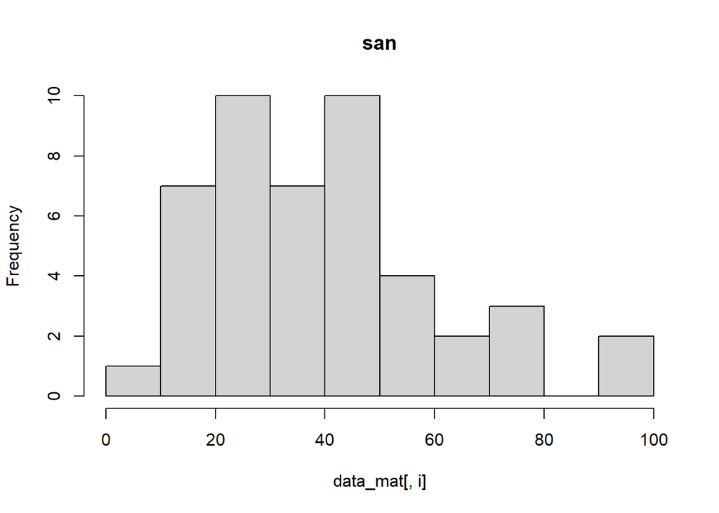

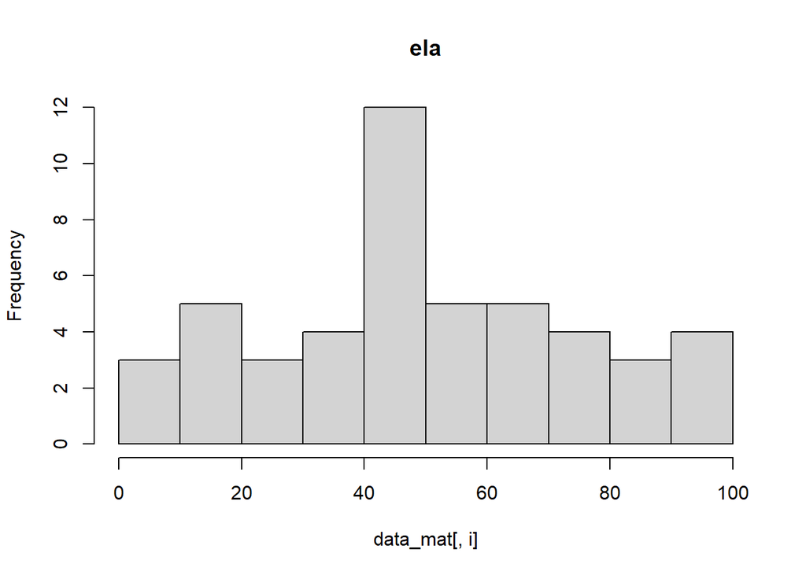

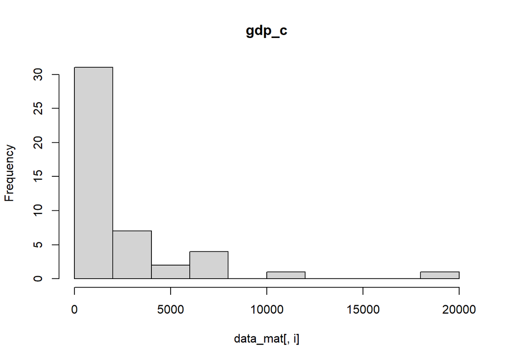

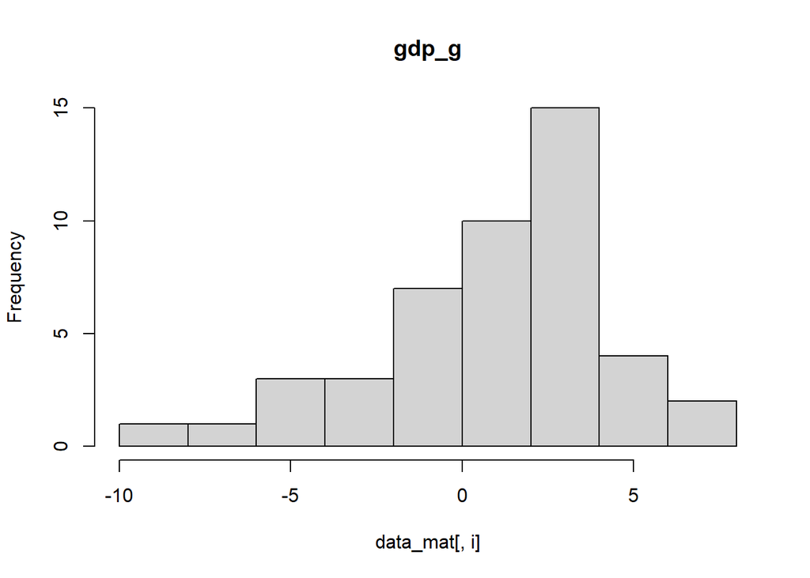

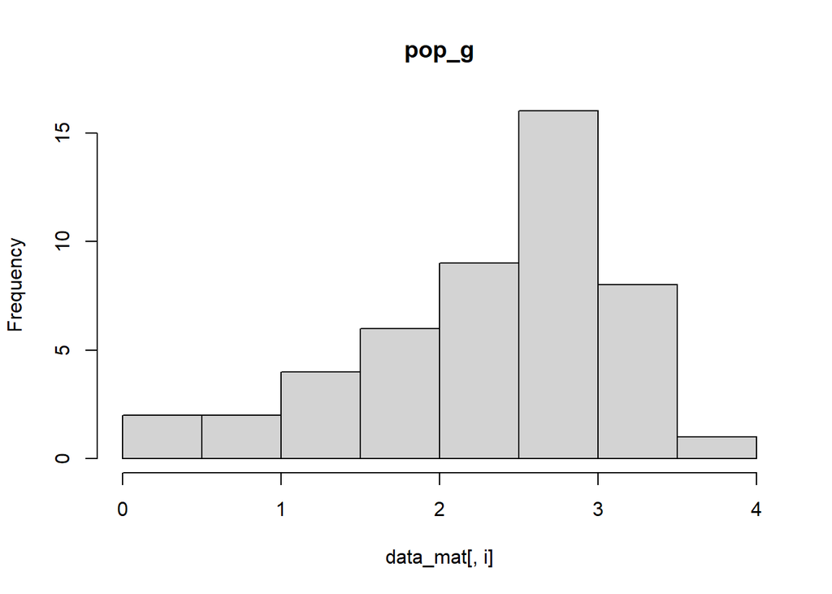

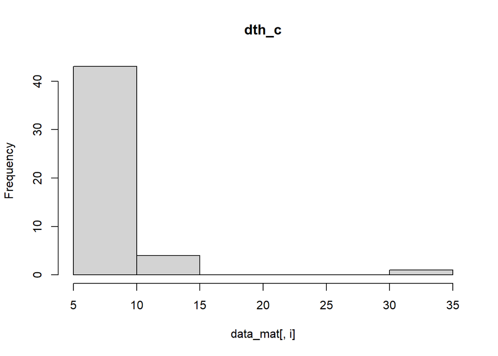

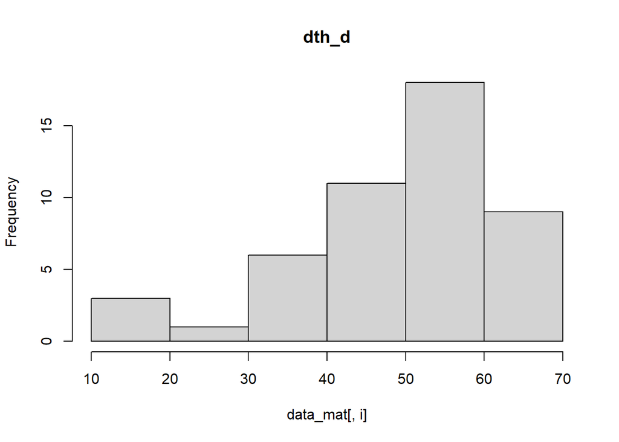

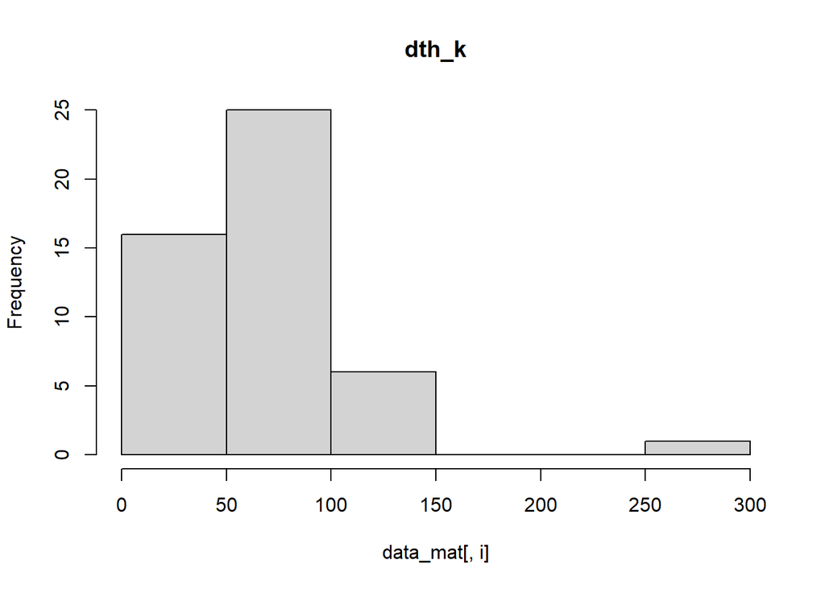

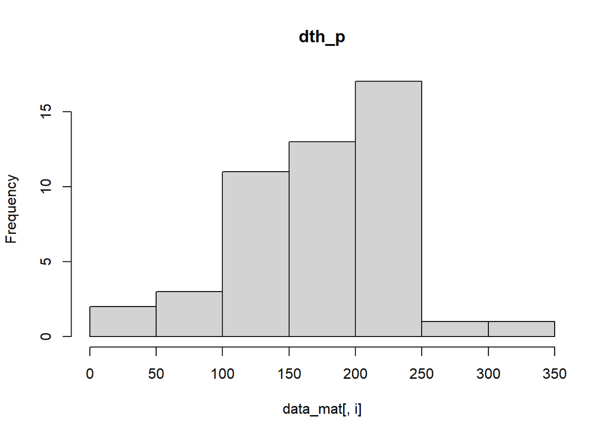

```r
#library(psych)
for (i in 1:9) {
  hist(data_mat[,i], main = colnames(data_mat)[i])
}
```

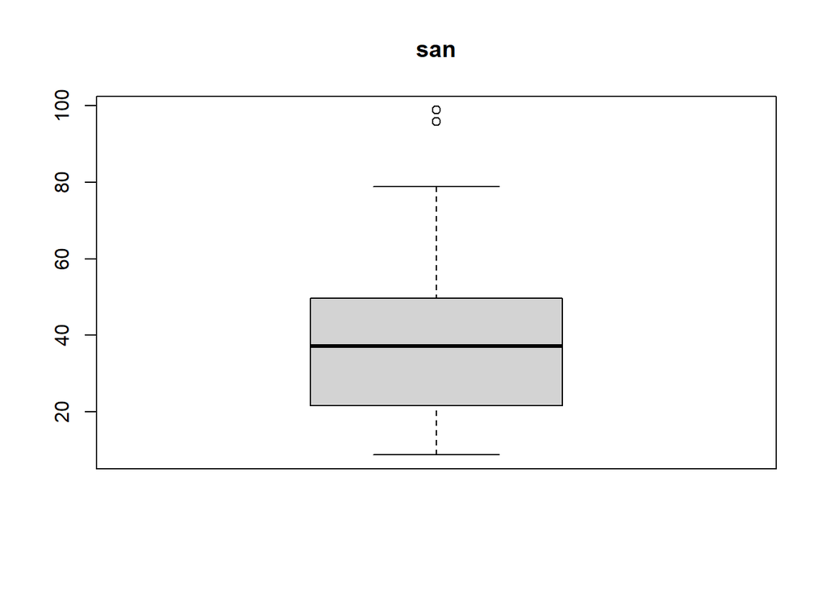

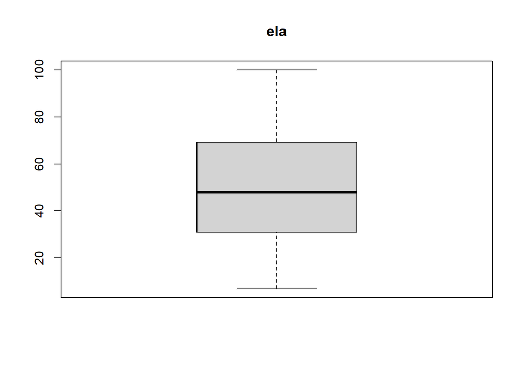

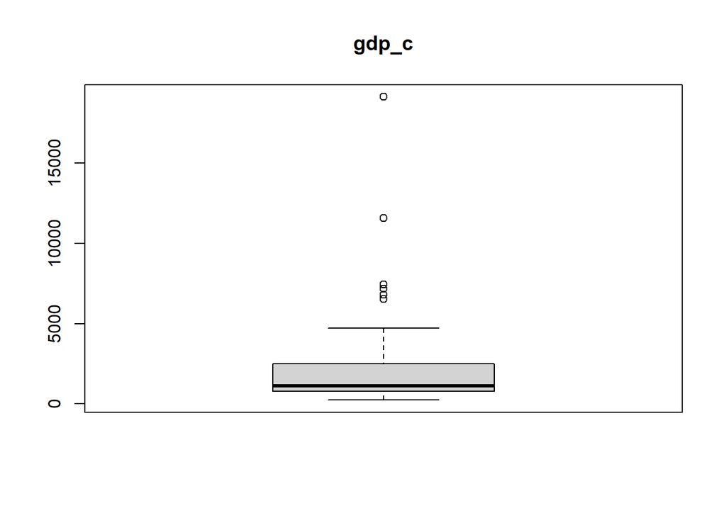

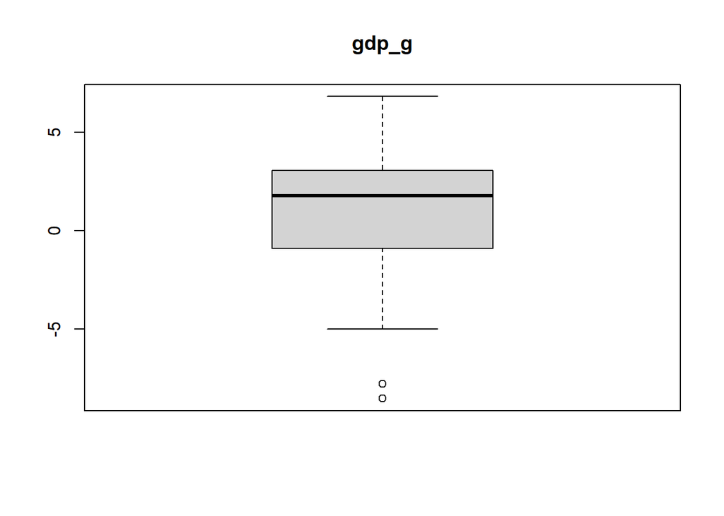

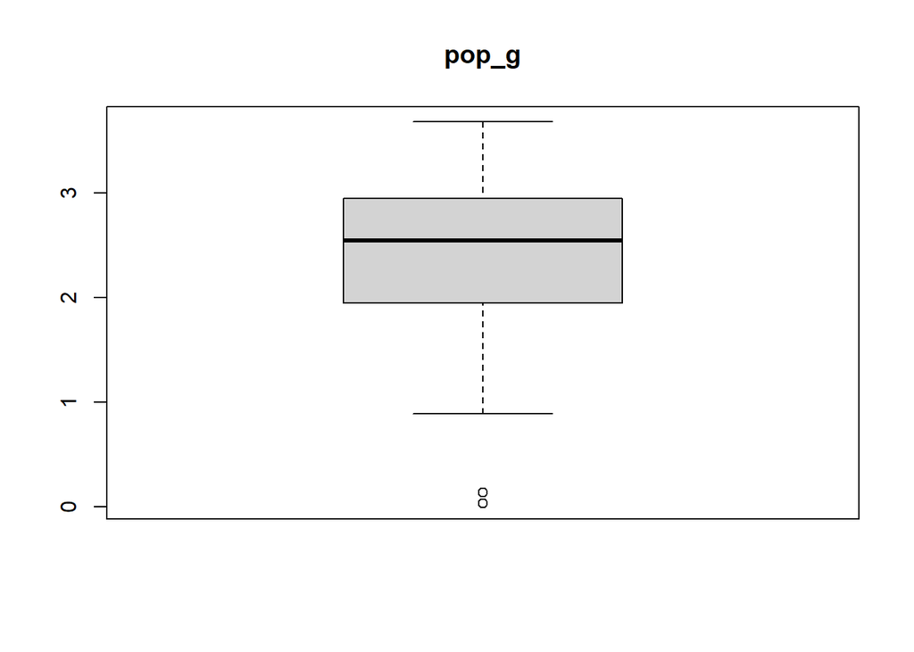

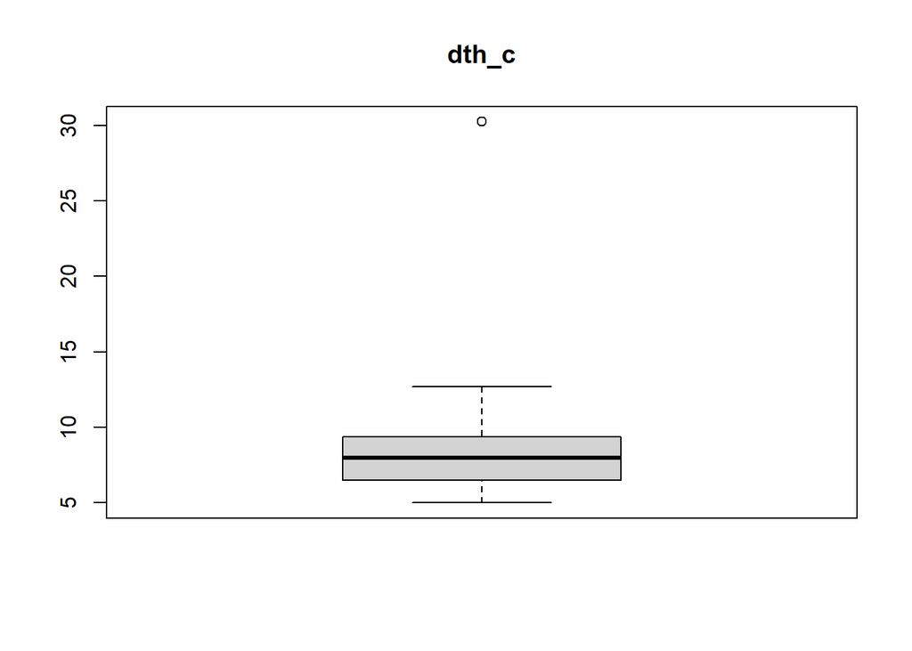

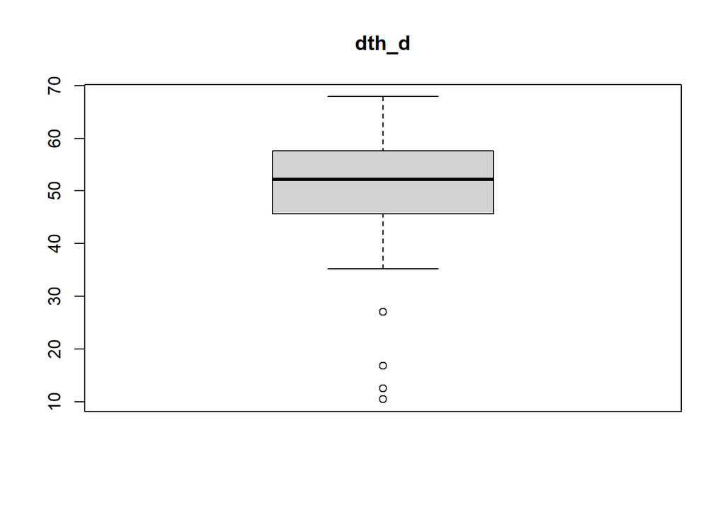

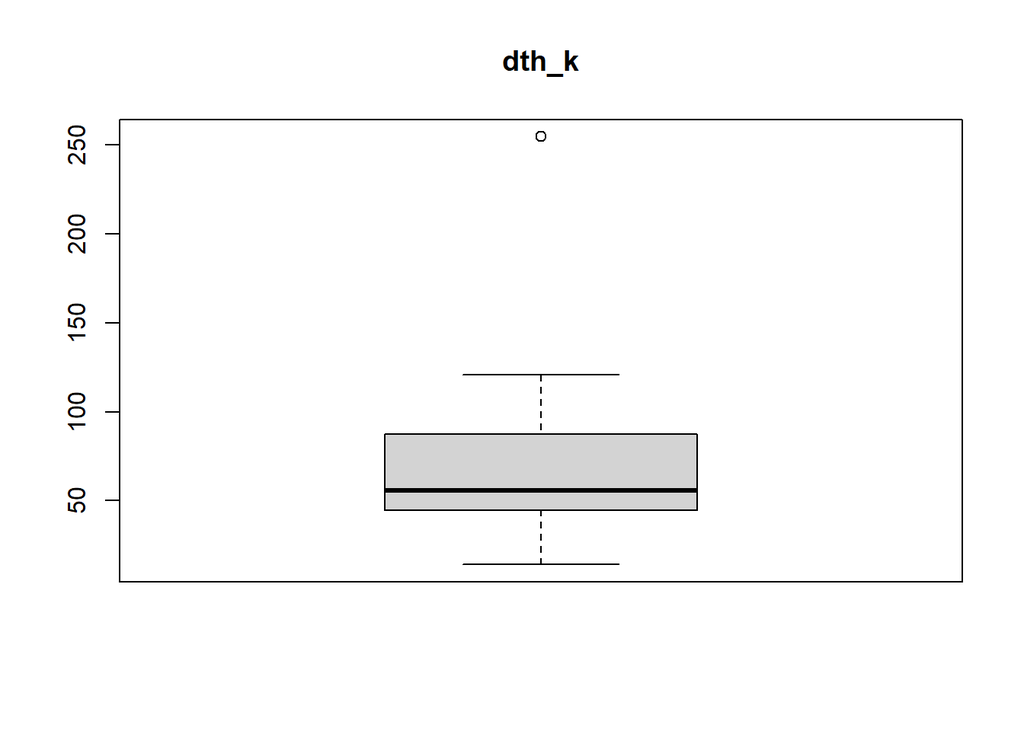

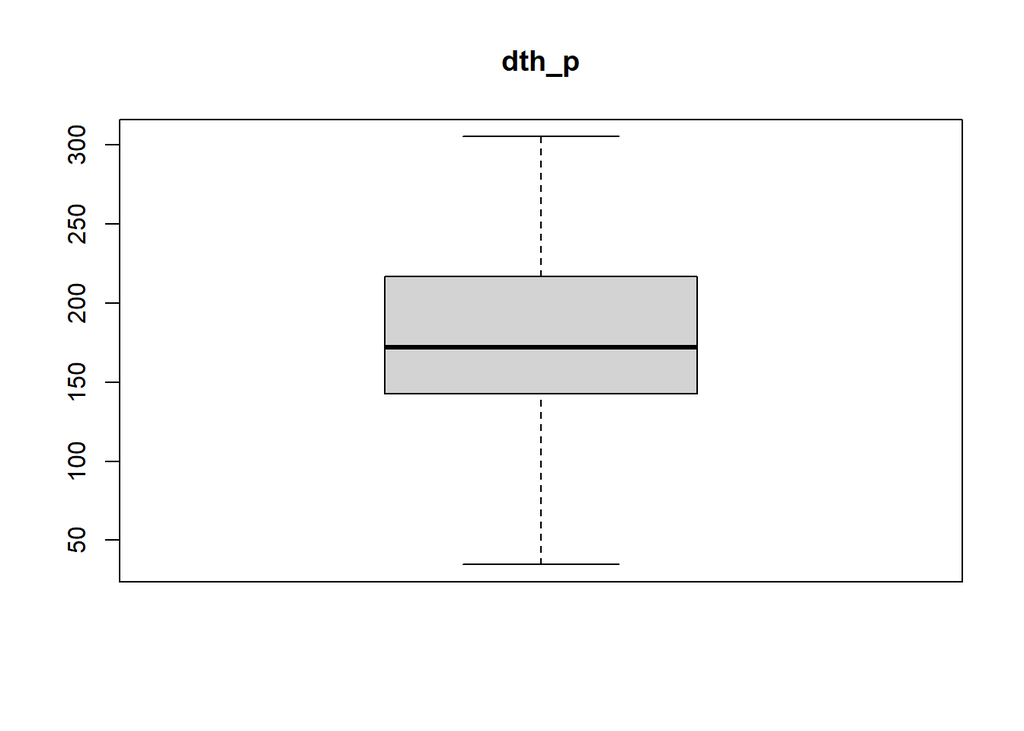

```r
for (i in 1:9) {
  boxplot(data_mat[,i], main = colnames(data_mat)[i])
}
```

```r
des <- describe(data_mat)
des
```

```
##       vars  n    mean      sd  median trimmed    mad    min      max    range
## san      1 46   39.49   21.70   37.11   37.42  21.16   8.68    98.89    90.20
## ela      2 48   49.87   25.08   47.80   49.40  27.35   6.80   100.00    93.20
## gdp_c    3 46 2516.03 3438.94 1106.44 1808.61 855.33 234.31 19141.51 18907.20
## gdp_g    4 46    1.02    3.45    1.77    1.26   2.76  -8.52     6.82    15.35
## pop_g    5 48    2.35    0.83    2.55    2.42   0.67   0.03     3.68     3.64
## dth_c    6 48    8.52    3.64    7.97    7.98   2.09   5.00    30.25    25.25
## dth_d    7 48   49.49   13.15   52.13   51.02   8.62  10.45    67.88    57.43
## dth_k    8 48   67.18   39.33   55.70   63.80  22.91  14.10   254.70   240.60
## dth_p    9 48  175.67   56.13  172.05  178.27  52.34  34.70   305.10   270.40
##        skew kurtosis     se
## san    0.86     0.30   3.20
## ela    0.14    -0.82   3.62
## gdp_c  2.98    10.22 507.04
## gdp_g -0.81     0.35   0.51
## pop_g -0.88     0.31   0.12
## dth_c  4.41    23.50   0.53
## dth_d -1.22     1.40   1.90
## dth_k  2.24     8.35   5.68
## dth_p -0.32     0.19   8.10
```

```r
#glimpse(data_mat)
#summary(data_mat)
```

The des file shows the number of data points, mean, standard deviatation, minimum value, maximum value, range, skew, kurtosis and more for each of the dimensions. Based on the information, we had a few important things we noticed.

- GDP per capita ($US) and death rate, crude (per 1,000 people) both have a very large skew and high kurtosis. As a result, it is possible that both dimensions will have to undergo some form of transformation. For GDP, the right skew appears to be caused by a few countries with a significantly higher GDP than the rest, which seem to be outliers.
- Mortality rate under 5 also appears to have a very high kurtosis and some possible outliers that contribute to the right skew of the data.
- Based on the boxplot, it appears that most dimensions have a few 1D outliers, specifically in GDP per capita, people using at least basic sanitation services, cause of death, by communicable diseases… , and population growth.

### Visualize and summarize the covariability between each pair of dimensions

The correlation plot shows two strong clusters of variables; Sanitation, elecritifaction, and GDP per capita form one, likely linked with wealth, and the death dimensions form another. GDP growth does not appear to have strong covariance with any other dimensions.

```r
cor_mat <- cor(x = data_mat, use = "pairwise.complete.obs")
cov_mat <- cov(x = data_mat, use = "pairwise.complete.obs")
cov_mat
```

```
##                san         ela         gdp_c       gdp_g         pop_g
## san     470.840715   402.51450    53152.6712   8.8848860   -10.3969833
## ela     402.514497   628.75606    56727.5961  10.1148751   -11.6028605
## gdp_c 53152.671229 56727.59614 11826307.9598 434.1242384 -1497.6157303
## gdp_g     8.884886    10.11488      434.1242  11.9168566    -0.7533285
## pop_g   -10.396983   -11.60286    -1497.6157  -0.7533285     0.6962814
## dth_c   -21.612403   -27.39997    -1200.7339  -0.6668427    -0.3608064
## dth_d  -216.118012  -227.23705   -26677.3587 -11.7429574     7.4026858
## dth_k  -498.979150  -587.70940   -54871.6732 -12.2756612     8.9640677
## dth_p  -775.657279  -785.08773  -133238.3398 -13.2687954    11.5701077
##               dth_c         dth_d         dth_k         dth_p
## san     -21.6124031   -216.118012   -498.979150    -775.65728
## ela     -27.3999688   -227.237046   -587.709397    -785.08773
## gdp_c -1200.7338869 -26677.358718 -54871.673228 -133238.33984
## gdp_g    -0.6668427    -11.742957    -12.275661     -13.26880
## pop_g    -0.3608064      7.402686      8.964068      11.57011
## dth_c    13.2811759     17.841729    123.766307      94.90349
## dth_d    17.8417287    172.810605    359.636015     415.80079
## dth_k   123.7663067    359.636015   1546.923121    1366.51326
## dth_p    94.9034922    415.800793   1366.513262    3150.14482
```

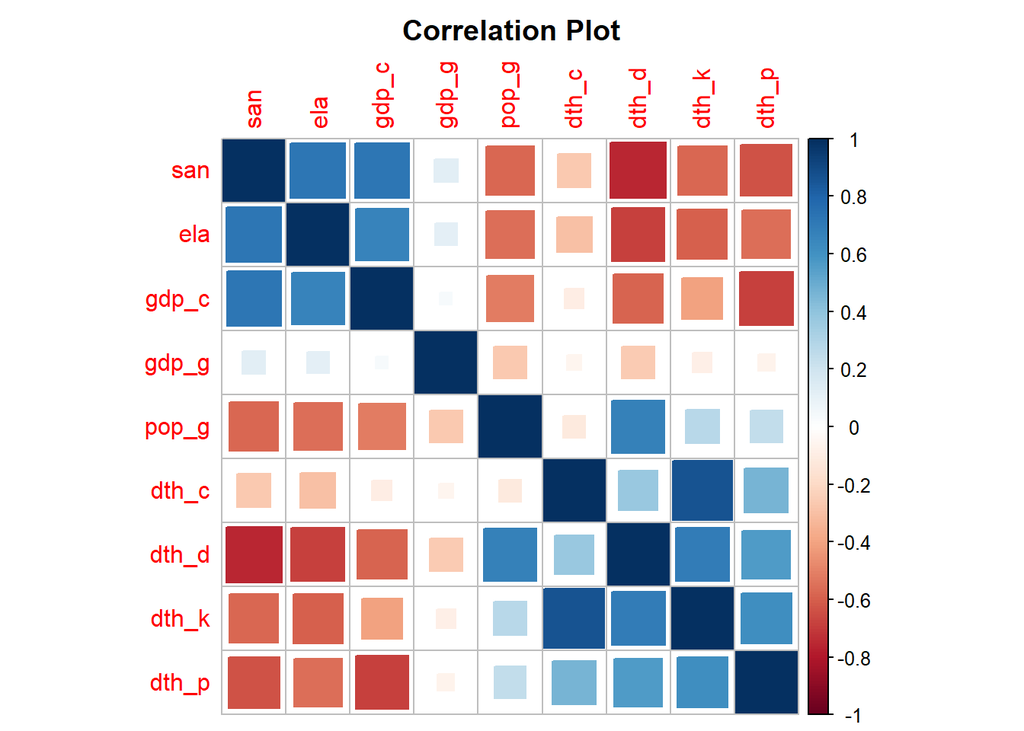

```r
corrplot(cor_mat,
         mar = c(0, 0, 2, 0),
         method = "square",
         title = "Correlation Plot")
```

The pairs.panels() function shows scatterplots and correlation coefficients for each pair of dimensions. Looking at the scatterplots, we can see that there is a strong linear relationship between sanitation and electricity. The extreme skewness of GDP per capita and crude death rate are also visible.

```r
pairs.panels(data_mat,
             oma = c(0, 0, 20, 0),
             main = "Scatterplot Matrix",
             gap = 0,
             smooth = FALSE,
             density = FALSE,
             ellipses = FALSE,
             yaxt = "n",
             xaxt = "n",
             cex.cor = 1,
             cex.main = 15,
             cex.labels = 15,
             cex = 10,
             pch = 1)
```

[figure not shown]

### Identify potential two-dimensional outliers and investigate their influence

Visually, there is a very high outlier in every pair with a death dimension, and two outliers in every pair with GDP per capita. We coded a custom function to calculate the Mahalanobis distance of every column pair per row. 34 pairs have Mahalanobis distances significant at alpha = 0.01.

- **The Central African Republic** (CAR) has the most outliers at 16, all linked to their extraordinarily high death rates. This is likely due to the CAR’s ongoing civil war and resulting humanitarian crisis, according to [Columbia University](https://www.publichealth.columbia.edu/news/extreme-mortality-rate-found-central-african-republic). These potential outliers are those visually identified above.
- **Seychelles and Maritius** also have a large number of outliers related to their extremely high electrification, sanitation, and GDPs, visually identified above. This is likely due to their status as small island nations, making them quite different from the rest of Africa.
- **Zimbabwe** has a single outlier in GDP growth X population growth as they have moderate population growth but severely declining GDP, which is not visually apparent. This is likely due to an economic crisis resulting from extreme public dept, [according to the IMF](https://www.imf.org/-/media/files/publications/cr/2019/1zweea2019003.pdf).

```r
mahalanobisPairs <- function(dm) {
  # Returns pairwise Mahalanobis distances for a numeric data matrix.
  # I apologize for the nasty triple-nested loop
  cn <- ncol(dm)
  rn <- nrow(dm)
  l <- 0
  means <- colMeans(dm, na.rm = TRUE)
  cvm <- cov(dm, use = "pairwise.complete.obs")
  trv <- (((cn - 1) ^ 2 + (cn - 1)) / 2)
  md <- data.frame(matrix(ncol = 4, nrow = trv * rn))
  colnames(md) <- c("row", "c1", "c2", "md")
  for(i in 1:rn) { # loops through rows
    for(j in 1:(cn - 1)) { # loops through columns except last
      for(k in (j + 1):cn) { # loops every other column
        l = l + 1
        dvn <- matrix(
          data = dm[i, c(j, k)] - c(means[j], means[k]),
          ncol = 2
        )
        sgm <- cvm[c(j, k), c(j, k)]
        md$row[l] <- rownames(dm)[i]
        md$c1[l] <- colnames(dm)[j]
        md$c2[l] <- colnames(dm)[k]
        md$md[l] <- dvn %*% solve(sgm) %*% t(dvn)
      }
    }
  }
  return(md)
}
md_df <- mahalanobisPairs(data_mat)
sig_df <- md_df[which(md_df$md > 9.21034),]
```

Removing the CAR, Seychelles, and Mauritius results in more condensed scatterplots, which are much easier to read. The high skewness in GDP per capita is still present but less pronounced.

```r
data_mat[-c(8, 30, 38), ] %>%
  pairs.panels(
             oma = c(0, 0, 20, 0),
             main = "Scatterplot Matrix Without Outliers",
             gap = 0,
             smooth = FALSE,
             density = FALSE,
             ellipses = FALSE,
             yaxt = "n",
             xaxt = "n",
             cex.main = 15,
             cex.cor = 1,
             cex.labels = 15,
             cex = 10,
             pch = 1)
```

[figure not shown]

Comparing the correlogram with the CAR, Seychelles, and Mauritius vs. without, it appears that the removal weakens the negative correlations between the death cluster and san/ela/gdp_c cluster. The positive correlations in the san/ela/gdp_c cluster are also weakened, likely due to Seychelles and Mauritius’ outliers in those pairs falling in the top right corner of their scatterplots, strengthening the correlations. Every correlation of deaths due to air pollution were also lowered.

Overall it may be appropriate to exclude the CAR from analysis as its unusual outliers are due to a unique (and hopefully temporary) civil war humanitarian crisis unrelated to environmental issues. Mauritius and the Seychelles are also highly distinct from the rest of Subsaharan Africa as they are small island nations not physically connected to the rest of the continent.

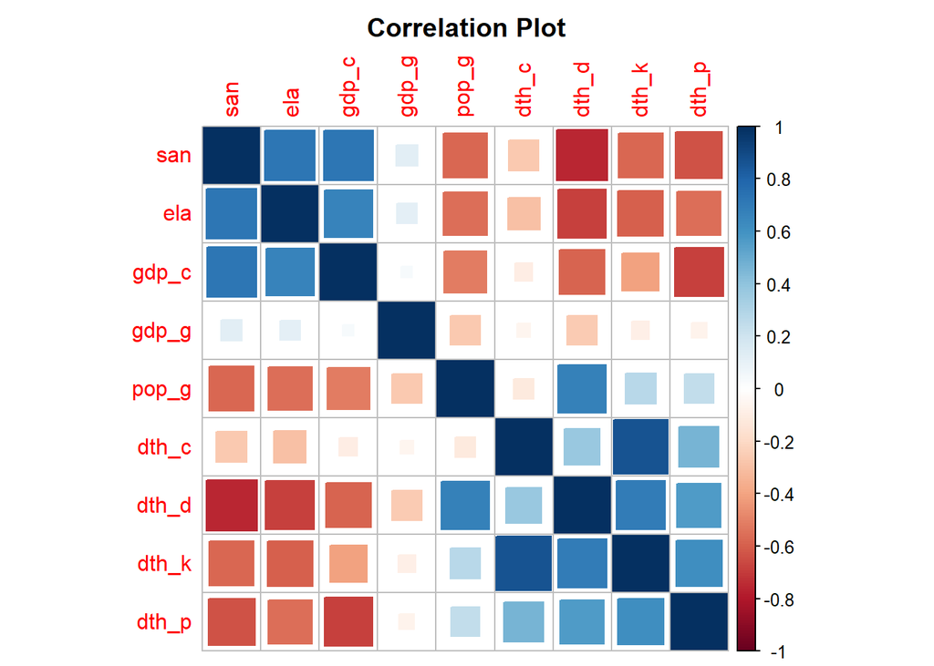

```r
corrplot(cor_mat,
         mar = c(0, 0, 2, 0),
         method = "square",
         title = "Correlation Plot")
```

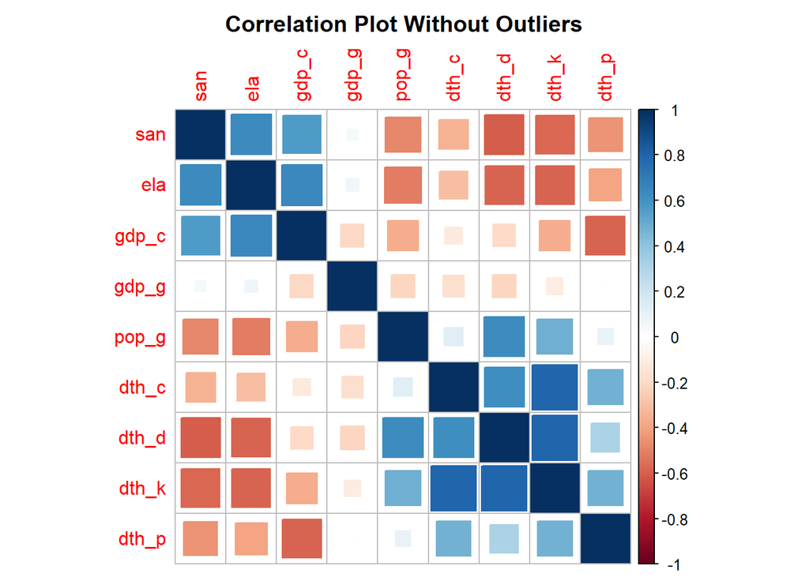

```r
cor(data_mat[-c(8, 30, 38), ], use = "pairwise.complete.obs") %>%
  corrplot(method = "square",
           mar = c(0, 0, 2, 0),
           title = "Correlation Plot Without Outliers")
```